# c6w7_trip_timofeev_beta

### Неделя 7 визуализация

Определитесь, в каком виде вы хотите представить ваш проект. Мы предлагаем вам сделать интерактивное демо, содержащее:

1. карты с визуализацией реального и прогнозируемого спроса на такси в выбираемый пользователем момент времени
2. временной ряд фактического и прогнозируемого спроса на такси в выбираемой области.

## Огромная просьба: проверьте, пожалуйста, работу недели 6

Я припознился и она зависла :( [c6w6_taxi](https://www.coursera.org/learn/data-analysis-project/peer/gtNEG/dopolnitiel-nyie-priznaki/review/2qfCyT1SEeiphArqg23QJg)

#### Cсылки

- [HTML](https://iliatimofeev.github.io/nytaxi/c6w7_trip_timofeev_beta.html) версия этого ноутбука
- [Dashboard](https://iliatimofeev.github.io/nytaxi/dashboard.html) итоговый живой HTML

> **Warning** данному ноутбуку нужны внешние файлы для отображения, поэтому я его выложил на github.io

#### Подход

Я пользуюсь библиотекой [altair](https://altair-viz.github.io), которая построена на базе [vega/vega-light](https://vega.github.io), которая в свою очередь построена на [d3](https://d3js.org/). d3 это одная из самых развитых библиотек визуализации в `javascript` мире, а вот vega это относительно молодой проект который достаточно быстро развивается и у них главная фишка это дескриптивный язык описания интерактивной графики. Картография не является для них приоритетом, но наконец ее частично дотянули до altair, хоть как-то внятно работать она начала только в 2.0.0rc2, которая вышла нескольо дней назад. Может не все получиться, но хоть в радикально перемотренном API разберусь.

```python
# грузим библиотеки
%matplotlib inline
%config InlineBackend.figure_format = 'retina'
import matplotlib.pyplot as plt

import pandas as pd
import numpy as np
import geopandas as gpd
import os.path
_fp = os.path.join
#from scipy import stats
#import statsmodels.api as sm
#import matplotlib.pyplot as plt
#import warnings
#from itertools import
import matplotlib as mpl
from itertools import cycle,product
from IPython.display import display, HTML,Image
import folium
from IPython.core.debugger import Tracer

def display_row(*objects,**options):
    class MultiObectRow(object):
        def _repr_html_(self):
            r =""
            format_str = ''.join(['{}:{};'.format(a,b) for a,b in options.items()])
            for obj in objects:
                if hasattr(obj,"_repr_html_"):
                    obj_str =obj._repr_html_()
                else: obj_str=str(obj)
                r+='<div class="col" style="{}">{}</div>'.format(format_str,obj_str)
            return '<div class="row" style="display: flex;">{}</div>'.format(r)
    return display(MultiObectRow())

def _ddf(df_data,caption = ""): # чуть больше информации о pd.DF
    display (HTML("<h4>{2}</h4><p>({0}, {1})</p>".format(df_data.shape[0],df_data.shape[1],caption)))
    #.cm-s-ipython span.cm-variable
    if df_data.shape[1]>10:
        #display (HTML('<p class="code">{}</p>'.format(str(df_data.columns).replace('\n     ',''))))
        display (HTML('<p style="font-family: monospace;">{}</p>'.format(str(df_data.columns).replace('\n     ',''))))

    if df_data.shape[1]<4:
        display_row(df_data.head(5),df_data.sample(5).sort_index(),df_data.tail(5),margin ="1px 5px")
    elif(df_data.shape[1]<6):
        display_row(df_data.head(5),df_data.sample(5).sort_index(),margin ="1px 5px")
    elif(df_data.shape[1]<10):
        display(df_data.head(1).append(df_data.sample(5).sort_index()).append(df_data.tail(1)))
    else:
        display(df_data.head(1).append(df_data.sample(3).sort_index()).append(df_data.tail(1)).T)

def _cc(clr): # контрастный цвет
    hsv = mpl.colors.rgb_to_hsv(clr)
    hsv[0] = hsv[0]+0.5 if hsv[0]<0.5 else hsv[0] -0.5
    return mpl.colors.hsv_to_rgb(hsv)
```

### 0. Данные прошлой недели

```python
df_kaggle =pd.read_csv(_fp('Data','w6_kaggele.csv'),index_col=0)
df_index = pd.Series(df_kaggle.index).str.split("_",expand=True).rename(columns={0:'area_id',1:'date',2:'hour',3:'i'})
df_kaggle.set_index([
    ((pd.to_datetime( df_index.date) + pd.to_timedelta(df_index.hour.astype(int),unit='H'))).rename('date'),
     df_index.area_id.astype(int),df_index.i],inplace=True)

_ddf(df_kaggle)
```

(437580, 1)

| date | area_id | i | y |
| --- | --- | --- | --- |
| 2016-05-31 23:00:00 | 1075 | 1 | 37.931161 |
|  |  | 2 | 16.471985 |
|  |  | 3 | 6.511645 |
|  |  | 4 | 2.959825 |
|  |  | 5 | 3.149172 |

| date | area_id | i | y |
| --- | --- | --- | --- |
| 2016-06-02 07:00:00 | 1184 | 2 | 34.850708 |
| 2016-06-05 09:00:00 | 2119 | 6 | 79.443124 |
| 2016-06-09 09:00:00 | 1180 | 5 | 734.649298 |
| 2016-06-18 22:00:00 | 1377 | 1 | 51.649468 |
| 2016-06-27 09:00:00 | 1287 | 4 | 71.468507 |

| date | area_id | i | y |
| --- | --- | --- | --- |
| 2016-06-30 17:00:00 | 2168 | 2 | 70.146153 |
|  |  | 3 | 80.330662 |
|  |  | 4 | 90.789335 |
|  |  | 5 | 96.843611 |
|  |  | 6 | 93.160632 |

```python
# таблица не содержит нулей - их нужно будет добавить
df_agg=pd.read_csv(_fp("data","yt_agg_good_regs.csv"),names = ['area_bin','pickup_time','trips'],
                      parse_dates = ['pickup_time'])
df_pt_trip =  df_agg.pivot_table( values = ['trips'],
                                  index =['pickup_time'],
                                  columns=['area_bin'],
                                  aggfunc='sum',fill_value=0)
```

```python
df_t = df_kaggle.unstack(['i','area_id']).groupby(
    level='i',axis=1).apply(lambda d: d.set_index(d.index+pd.to_timedelta(int(d.name),'h')))

df_t.columns =df_t.columns.droplevel([0,1])
df_t=df_t.join(df_pt_trip)
display_row(df_t.sample(5,axis=1).head(7),df_t.sample(5,axis=1).tail(7))
```

| i area_id date | 3 1434 | 1 1283 | 4 1434 | 5 1783 | 2 1336 |
| --- | --- | --- | --- | --- | --- |
| 2016-06-01 00:00:00 | NaN | 98.428844 | NaN | NaN | NaN |
| 2016-06-01 01:00:00 | NaN | 23.810048 | NaN | NaN | 16.674205 |
| 2016-06-01 02:00:00 | 1.111274 | -4.138821 | NaN | NaN | 12.670257 |
| 2016-06-01 03:00:00 | 0.912785 | -12.637098 | 0.912785 | NaN | 10.387479 |
| 2016-06-01 04:00:00 | 1.590072 | -4.415449 | 1.590072 | -9.947146 | 12.483231 |
| 2016-06-01 05:00:00 | 4.060801 | 23.466117 | 4.060801 | 20.840832 | 23.340426 |
| 2016-06-01 06:00:00 | 12.725932 | 111.735708 | 12.725932 | 71.935596 | 64.394310 |

| i area_id date | 2 1077 | 3 1437 | 4 1125 | 6 1075 | 3 1438 |
| --- | --- | --- | --- | --- | --- |
| 2016-06-30 17:00:00 | 110.848413 | 32.318310 | 81.107800 | 110.087663 | 10.269643 |
| 2016-06-30 18:00:00 | 152.448750 | 32.220577 | 111.958976 | 122.487018 | 10.168118 |
| 2016-06-30 19:00:00 | 161.356568 | 26.093665 | 125.287696 | 121.613056 | 8.416005 |
| 2016-06-30 20:00:00 | NaN | 23.288054 | 124.927889 | 115.316317 | 7.374700 |
| 2016-06-30 21:00:00 | NaN | NaN | 123.238189 | 113.338972 | NaN |
| 2016-06-30 22:00:00 | NaN | NaN | NaN | 102.115499 | NaN |
| 2016-06-30 23:00:00 | NaN | NaN | NaN | 82.573986 | NaN |

```python
df_data= df_t.unstack().rename('val').reset_index()
_ddf(df_data)
```

(514080, 4)

|  | i | area_id | date | val |
| --- | --- | --- | --- | --- |
| 0 | 1 | 1075 | 2016-06-01 00:00:00 | 37.931161 |
| 1 | 1 | 1075 | 2016-06-01 01:00:00 | 16.471985 |
| 2 | 1 | 1075 | 2016-06-01 02:00:00 | 6.511645 |
| 3 | 1 | 1075 | 2016-06-01 03:00:00 | 2.959825 |
| 4 | 1 | 1075 | 2016-06-01 04:00:00 | 3.149172 |

|  | i | area_id | date | val |
| --- | --- | --- | --- | --- |
| 234079 | 4 | 1180 | 2016-06-04 07:00:00 | 258.590360 |
| 296091 | 5 | 1125 | 2016-06-08 03:00:00 | 12.577629 |
| 370796 | 6 | 1126 | 2016-06-30 20:00:00 | 333.705450 |
| 380304 | 6 | 1179 | 2016-06-07 00:00:00 | 313.235065 |
| 507445 | trips | 1630 | 2016-06-24 13:00:00 | 2.000000 |

Координаты областей на карте, были в исходных данных задачи

```python
df_reg = pd.read_csv(_fp("data","regions.csv"),sep=';',index_col=['region'])
df_reg = df_reg.reindex(df_data.area_id.unique())
_ddf(df_reg)
```

(102, 4)

| region | west | east | south | north |
| --- | --- | --- | --- | --- |
| 1075 | -74.022246 | -74.011135 | 40.697437 | 40.705825 |
| 1076 | -74.022246 | -74.011135 | 40.705825 | 40.714213 |
| 1077 | -74.022246 | -74.011135 | 40.714213 | 40.722601 |
| 1125 | -74.011135 | -74.000023 | 40.697437 | 40.705825 |
| 1126 | -74.011135 | -74.000023 | 40.705825 | 40.714213 |

| region | west | east | south | north |
| --- | --- | --- | --- | --- |
| 1230 | -73.988912 | -73.977800 | 40.739378 | 40.747766 |
| 1378 | -73.955577 | -73.944465 | 40.722601 | 40.730990 |
| 1431 | -73.944465 | -73.933354 | 40.747766 | 40.756154 |
| 1480 | -73.933354 | -73.922242 | 40.739378 | 40.747766 |
| 1533 | -73.922242 | -73.911130 | 40.764542 | 40.772931 |

Мы планируем показывать на карте количество вызовов, можно конечно показать красиву ровную шкалу цвета, но класики вызуалиазации не рекомендуют так делать ибо глаз достаточно полохо считывает токие разницы в цвете на карте. Рекомендуеться бинить на пять-семь групп и показывать уже цвета группы. Обычно и в нашем случае бинить даннные линейно достаточно бессмыслено, получится одна - две яркие точки на карте, а остальное будет однинакого цвета. Достаточно стандартное решение логарифмировать данные, чтобы как-то растянуть градации. Чтобы не грузить этими вычислениями javascript подготовим такую разбивку данных.

```python
df_binned = df_data.copy()
df_binned.loc[df_binned.val<=10,['val']]=np.NaN
df_binned['log'] = np.log(df_binned.val)
#df_binned['bin'] = pd.cut(df_binned.log,5)
#df_binned.groupby('bin').size()
df_binned['bin'], bins = pd.cut(df_binned.log,4,retbins=True,include_lowest=True)
np.exp(bins)
```

```
array([    9.94710485,    37.88564796,   143.52874464,   543.75473696,
        2060.        ])
```

Тут вот какая тонкость - настоящие границы логарифмичесих бинов на легенде будут выглядеть страшно, vega в таких случаеях включает магию nice и как-то округляет данные, чтобы они читались. А тут я просто ручками округлю до красивых цифр

```python
df_data['val']=df_data.val.round().fillna(0).astype(int) #заодно уберем запятые в прогнозе
df_data['val_bin']=pd.cut(df_data.val,[0,10,40,150,550,2100],labels = ['0-10','10-40','40-150','150-550','550+'],include_lowest=True)
```

Мой текущий прогноз не зависит от i - сдвига, я оставлю только 1, чтобы быстрее работало

```python
df_t = df_data[df_data.i.isin(['1','trips'])].set_index(['i','area_id','date']
                                            ).unstack('i'
                                            ).reset_index(
                                            )
df_t.columns = ['area_id', 'date', 'predict', 'trips','predict_bin', 'trips_bin']

csv_data = 'display_data.csv'
df_t = df_t.merge(df_reg,left_on='area_id',right_index=True).dropna()

df_t.to_csv(csv_data)
_ddf(df_t)
```

(71423, 10)

|  | 0 | 35427 | 39985 | 48725 | 73439 |
| --- | --- | --- | --- | --- | --- |
| area_id | 1075 | 1286 | 1333 | 1383 | 2168 |
| date | 2016-06-01 00:00:00 | 2016-06-07 03:00:00 | 2016-06-17 01:00:00 | 2016-06-21 05:00:00 | 2016-06-30 23:00:00 |
| predict | 38 | 44 | 115 | 83 | 0 |
| trips | 26 | 16 | 87 | 80 | 0 |
| predict_bin | 10-40 | 40-150 | 40-150 | 40-150 | 0-10 |
| trips_bin | 10-40 | 10-40 | 40-150 | 40-150 | 0-10 |
| west | -74.0222 | -73.9778 | -73.9667 | -73.9556 | -73.7778 |
| east | -74.0111 | -73.9667 | -73.9556 | -73.9445 | -73.7667 |
| south | 40.6974 | 40.7897 | 40.7645 | 40.7645 | 40.6387 |
| north | 40.7058 | 40.7981 | 40.7729 | 40.7729 | 40.6471 |

### 1. Карты с визуализацией реального и прогнозируемого спроса на такси в выбираемый пользователем момент времени

```python
import altair as alt
alt.renderers.enable('notebook')#
```

К сожадению tile map altair пока не умеет подкладывать но у меня нашласть векторная карта NY, попробуем ее как фон

[interactive chart not shown]

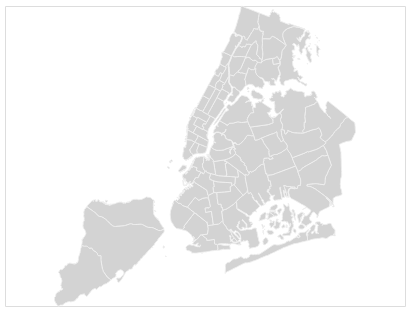

```python
ny_topo = alt.topo_feature('https://iliatimofeev.github.io/nytaxi/nyc_police_precincts-topojson.json', 'nyc_police_precincts')
ny_map = alt.Chart(ny_topo).mark_geoshape(
    stroke='#eee',
    strokeWidth=1
).properties(
    projection={'type': 'mercator',
                #'clipExtent':[[-74.022246,40.638719],[-73.766680,40.848424]]
               },
    width=400,
    height=300
).encode(
    fill = alt.value('lightgray'),
)
ny_map
```

```python
url_csv_data = "https://iliatimofeev.github.io/nytaxi/"+csv_data
```

Данные на 2016-06-06 23:00:00

Можно выделить область кликом, в tooltip показывает вызовы

[interactive chart not shown]

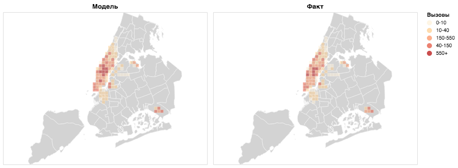

```python
selector = alt.selection_single(empty='none', fields=['area_id'])


res_map=alt.Chart().mark_rect(
    fillOpacity = .7,
    strokeOpacity = 0.3,
    strokeWidth = 1,
    filled =False,
    color='white'#lightgray

).encode(
    longitude = 'west:Q',
    latitude = 'north:Q',
    longitude2 = 'east:Q',
    latitude2 = 'south:Q',
    fill=alt.condition(selector,
                       alt.value('#2b83ba'),
                       alt.Color('val_bin',
                                 type='ordinal',
                             scale=alt.Scale( range=['#fef0d9','#fdcc8a','#fc8d59','#e34a33','#b30000']),
                             legend=None,
                           ),
                       legend=None,

                      ),
   opacity = alt.condition(
                           selector,
                           alt.value(1),
                           alt.value(0.7),

                        ),
   tooltip = 'val:Q',

).transform_filter(
     alt.FieldEqualPredicate(field='date', equal='2016-06-06 23:00:00')


).properties(
    selection=selector,
    #title = alt.repeat('column')
)
legend = alt.Chart(
    ).mark_circle(fillOpacity = 0,
    ).encode(
    color = alt.Color(
        'predict_bin',type='ordinal',
         scale=alt.Scale( range=['#fef0d9','#fdcc8a','#fc8d59','#e34a33','#b30000']),
         legend = alt.Legend(title="Вызовы")
        ),
    )

base_map = alt.layer(ny_map,res_map,legend)


display(HTML("<h3>Данные на 2016-06-06 23:00:00 </h3>  <p>Можно выделить область кликом, в tooltip показывает вызовы</p>"))

alt.hconcat(
    base_map.transform_calculate(
                val_bin='datum.predict_bin',
                val='datum.predict'
            ).properties(
                title = 'Модель'
            ),
    base_map.transform_calculate(
                val_bin='datum.trips_bin',
                val='datum.trips'
            ).properties(
                title = 'Факт'
            ),
data = url_csv_data)
```

Логично показать детализацию по выбраной области

Данные на вызовов Такси

Можно выделить область кликом, в tooltip показывает вызовы  
Можно выделить время кликом. Колесом можно приблить ряд

[interactive chart not shown]

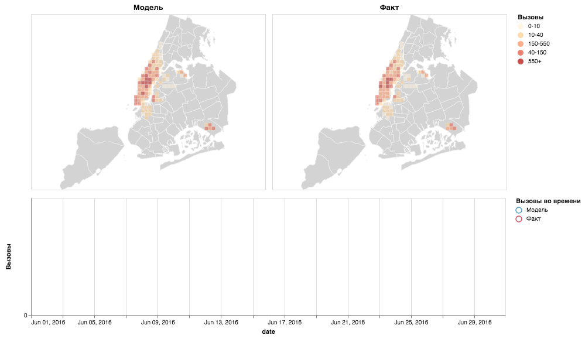

```python
nearest = alt.selection(type='single', nearest=True, #on='mouseover',
                        fields=['date'], empty='none')

line_trips = alt.Chart(
    ).mark_line(
    ).encode(
        x='date:T',
        y =alt.Y('trips:Q', axis=alt.Axis( title='Вызовы')),
        color = alt.value('#ca0020'),
        opacity = alt.value(0.7),
        tooltip='trips:Q',
    ).properties(
        width=810,
        height=200,
    ).transform_filter(
        selector
    )

line_predict = alt.Chart(
    ).encode(
        x='date:T',
        y =alt.Y('predict:Q', axis=alt.Axis( title='Вызовы')),
        color = alt.value('#0571b0'),
        opacity = alt.value(0.7),
        tooltip='predict:Q',

    ).transform_filter(
        selector
    ).mark_line(
    )

selectors = alt.Chart().mark_point().encode(
    x= 'date:T',
    opacity=alt.value(0),
).properties(
    selection=nearest
).interactive()
# Draw a rule at the location of the selection
rules = alt.Chart().mark_rule(color='#92c5de').encode(
    x='date:T',
    tooltip = 'predict:N'
).transform_filter(
    nearest.ref()
)

line_legend = alt.Chart(alt.InlineData([{'c':'Модель'},{'c':'Факт'}])
    ).mark_point(fillOpacity = 0,
    ).encode(
        color = alt.Color(
            'c',type='ordinal',
             scale=alt.Scale( range=['#0571b0','#ca0020']),
             legend = alt.Legend(title="Вызовы во времени")
            ),
        opacity = alt.value(0)
    )

display(HTML("<h3>Данные на вызовов Такси </h3>  <p>Можно выделить область кликом, в tooltip показывает вызовы <br>\
            Можно выделить время кликом.  Колесом можно приблить ряд</p>"))

chart = alt.vconcat(
           alt.hconcat(
                base_map.transform_calculate(
                            val_bin='datum.predict_bin',
                            val='datum.predict'
                        ).properties(
                            title = 'Модель'
                        ),
                base_map.transform_calculate(
                            val_bin='datum.trips_bin',
                            val='datum.trips'
                        ).properties(
                            title = 'Факт'
                        )
            ),
            alt.layer(
                line_trips,
                line_predict,
                selectors,
                rules,
                line_legend,

            ).resolve_axis(
                x='shared'
            ),
            data=url_csv_data
        ).resolve_scale(color ='independent'
        ).resolve_legend(color ='independent',
        )
chart
```

```python
chart.savechart('dashboard.html')
```